# Laboratorio 4

Lettura dati:

```r
require(geoR)           # carica il pacchetto geoR
```

```r
dat.om<-soja98; str(dat.om)
```

```
## 'data.frame':    256 obs. of  10 variables:
##  $ X    : num  5.6 15.2 24.8 34.4 44 53.6 63.2 72.8 82.4 92 ...
##  $ Y    : num  3.6 1.6 4.6 5.6 1.6 1.6 2.6 4.6 3.6 2.6 ...
##  $ P    : num  4.4 3.7 3.5 3.9 3.6 3.7 2.9 2.2 3 2.7 ...
##  $ PH   : num  6.3 6.3 5.4 5.2 5.6 5.2 5.2 5.6 5.7 5.4 ...
##  $ K    : num  0.53 0.38 0.47 0.48 0.52 0.45 0.47 0.42 0.36 0.35 ...
##  $ MO   : num  47.5 48.7 51.8 57.9 59.7 ...
##  $ SB   : num  80.6 82.2 61.5 59.1 71.6 ...
##  $ iCone: num  31 29.5 23 24.5 18.5 21.5 13 23 20 20 ...
##  $ Rend : num  6.4 7.05 5.88 8.52 7.47 ...
##  $ PROD : num  2.56 2.82 2.35 3.41 2.99 3.73 2.91 3.47 3 3.58 ...
```

```r
obj <- dat.om[,c("X","Y","MO")]
summary(obj)
```

```
##        X                Y                MO
##  Min.   :  1.60   Min.   :  1.60   Min.   :36.55
##  1st Qu.: 38.60   1st Qu.: 29.60   1st Qu.:48.07
##  Median : 75.60   Median : 57.60   Median :53.61
##  Mean   : 75.85   Mean   : 57.29   Mean   :52.55
##  3rd Qu.:112.60   3rd Qu.: 85.60   3rd Qu.:56.97
##  Max.   :149.60   Max.   :113.60   Max.   :68.35
```

```r
attach(obj)
```

Variogramma empirico:

```r
soja.geo <- as.geodata(obj,coords.col=1:2,data.col=3)
soja.var <- variog(soja.geo, estimator.type="classical")
```

```
## variog: computing omnidirectional variogram
```

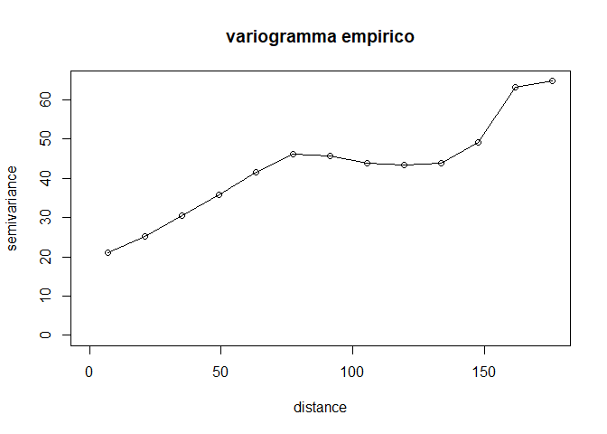

```r
plot(soja.var, main="variogramma empirico", type="o")
```

Stima variogramma con WLS:

```r
soja.var.fit <-variofit(soja.var,ini.cov.pars=c(25,35),weights="cressie",
        cov.model="exponential", fix.nugget=FALSE,nugget=20)
```

```
## variofit: covariance model used is exponential
## variofit: weights used: cressie
## variofit: minimisation function used: optim
```

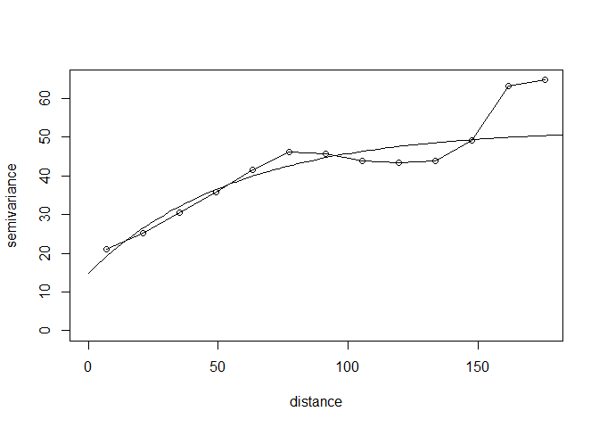

```r
plot(soja.var, type="o")
lines(soja.var.fit)
```

```r
a<-soja.var.fit$cov.pars
```

Preparazione griglia di previsione:

```r
 size=30
#seq tra min e max delle ordinate:
#creo un grigliato che copre esattamente il campo di variazione
YY<-round(seq(ceiling(min(Y)),floor(max(Y)), length=size),2)
XX<-round(seq(ceiling(min(X)),floor(max(X)), length=size),2)
griglia<-expand.grid(X=XX,Y=YY)
dim(griglia) #ordinate e ascisse dei 900 quadrati della griglia 30x30
```

```
## [1] 900   2
```

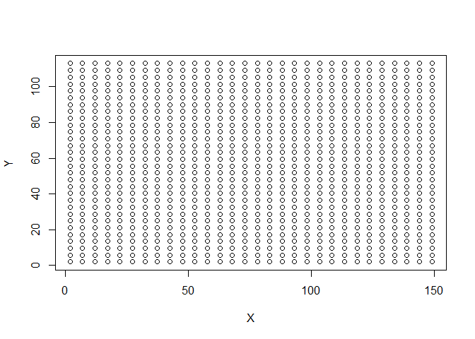

```r
plot(griglia)
```

non avendo uno shape, dobbiamo creare noi lo spazio in cui ci sono info

## Previsione con kriging ordinario

applichiamo il kriging ad ogni punto di questa griglia, per ogni punto calcoliamo la previsione come combinazione lineare di tutti i punti campionari; per 900 volte calcoliamo inversa matrice Gamma e vettore gamma

```r
krg.or <- krige.conv(geodata=soja.geo,
                  loc=griglia,
                    krige=krige.control(cov.pars=a,
                              cov.model="exponential",
                              nugget=soja.var.fit$nugget))
```

```
## krige.conv: model with constant mean
## krige.conv: Kriging performed using global neighbourhood
```

`geodata` = dati, `loc` = locazioni delle previsioni (griglia), `krige` = struttura di correlazione costruita preliminarmente, `krige.control` = stime soglia parziale e range salvate in `a`, `cov.model` = esponenziale, `nugget` = stima nugget con WLS.

```r
names(krg.or)
```

```
## [1] "predict"      "krige.var"    "beta.est"     "distribution"
## [5] "message"      "call"
```

Rappresentazione grafica della previsione:

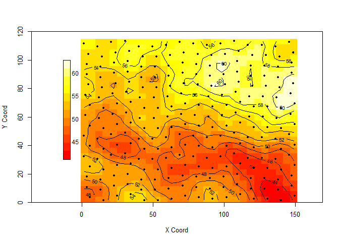

```r
par(cex=0.8)

# primo grafico
image(krg.or,xlim=c(-15,floor(max(X))),ylim=c(0,120))
legend.krige(x.leg=c(-13,-8), y.leg=c(30,100), val=krg.or$predict,
            vert=TRUE, off=0.7, cex=0.9, scale.vals=pretty(krg.or$predict)
            )
# curve di livello
contour(krg.or,add=T,coords.data=soja.geo$coords,cex=0.3)
```

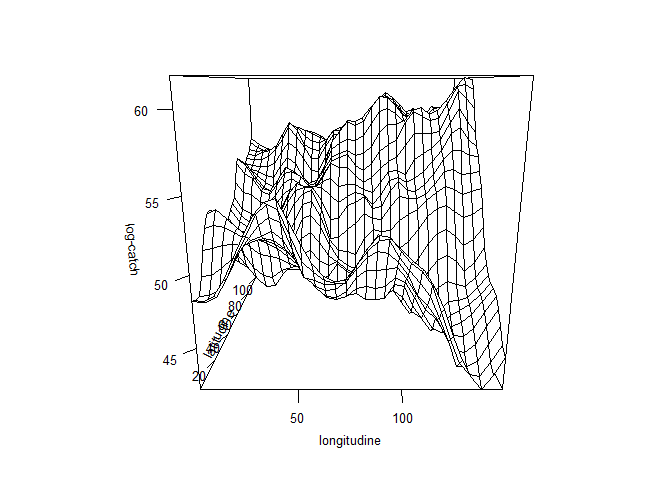

```r
# secondo grafico - 3d (persp)
persp(krg.or,xlab="longitudine",ylab="latitudine",zlab="log-catch",ticktype="detailed")
```

In questi due grafici ho rappresentato la previsione con sfumature di colore / con un grafico 3d.

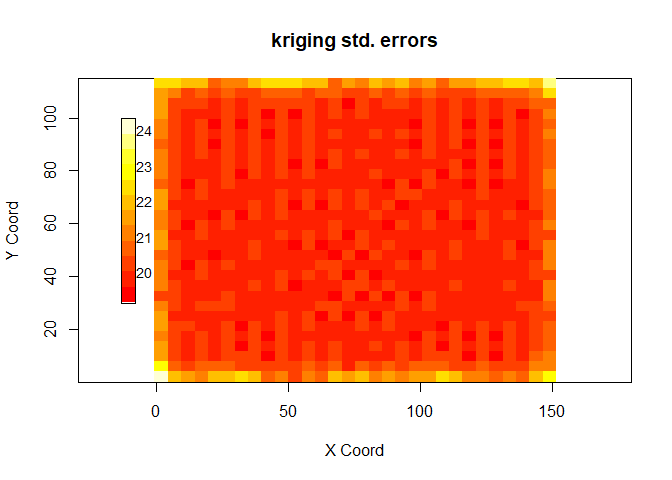

```r
# terzo grafico
image(krg.or, val=sqrt(krg.or$krige.var), main="kriging std. errors",
        xlim=c(min(X),floor(max(X))))
legend.krige(x.leg=c(-13,-8), y.leg=c(30,100), val=krg.or$krige.var,
        vert=TRUE, off=0.7, cex=0.9, scale.vals=pretty(krg.or$krige.var)
    )
```

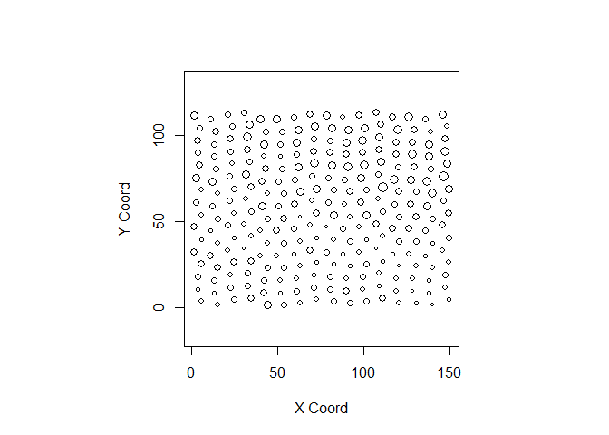

```r
# quarto grafico
points.geodata(soja.geo,pt.divide="data.proportional")
```

rappresentazione dei punti campionari usati per la stima, sono più grandi quanto più alto è il valore rilevato lì. possiamo vedere se è coerente con le previsioni fatte sulla base di quelle osservazioni.

## Kriging universale

si detrendizza e in un secondo momento si stima il variogramma;

Variogramma empirico su dati detrendizzati da geor

```r
obj.var.u <- variog(soja.geo, estimator.type="classical",trend="2nd")
```

```
## variog: computing omnidirectional variogram
```

stima regressione, calcola $\hat{y}$, calcola residui e calcola variogramma su di essi

```r
obj.var.fit.u <- variofit(obj.var.u,
      ini.cov.pars=c(10,40),    cov.model="exponential", fix.nugget=FALSE,nugget=15)
```

```
## variofit: covariance model used is exponential
## variofit: weights used: npairs
## variofit: minimisation function used: optim
```

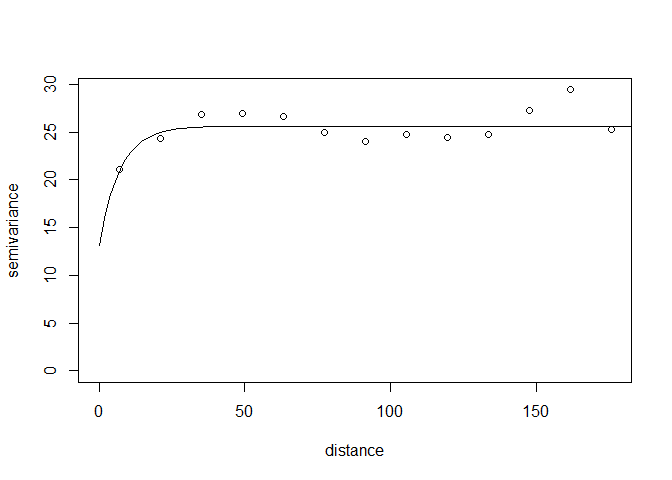

```r
plot(obj.var.u)
  lines(obj.var.fit.u)
```

kriging universale (uk)

```r
krg.uk <- krige.conv(geodata=soja.geo,
                loc=griglia,
                krige=krige.control(type.krige = "ok",#universale ma si deve mettere ok
                                    trend.d="2nd",
                                    trend.l="2nd",
                                    cov.pars=obj.var.fit.u$cov.pars,
                                    nugget=obj.var.fit.u$nugget,
                                    cov.model="exponential"
                ))
```

```
## krige.conv: model with mean given by a 2nd order polynomial on the coordinates
## krige.conv: Kriging performed using global neighbourhood
```

`trend.d` e `trend.l` specificano il trend che vogliamo usare nel ku; polinomio di secondo grado completo di latitudine e longitudine

**Previsione**:

modello con fz delle medie polinomio di secondo ordine - il resto è uguale al kriging ordinario

Rappresentazione grafica della previsione

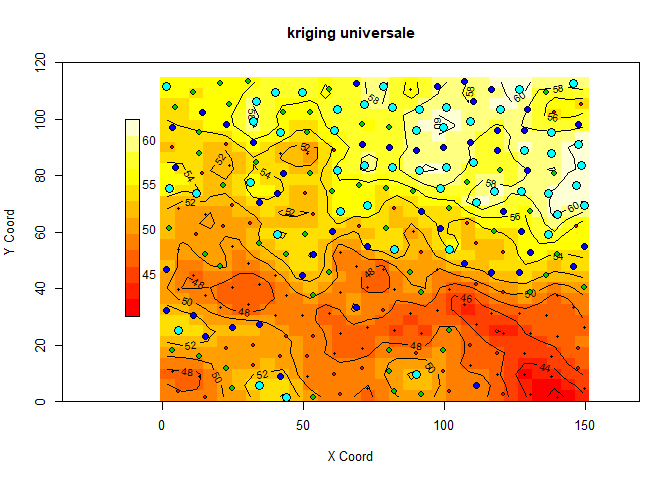

```r
par(cex=0.8)
image(krg.uk, main="kriging universale",xlim=c(-15,floor(max(X))),ylim=c(0,120))
legend.krige(x.leg=c(-13,-8), y.leg=c(30,100), val=krg.uk$predict,
  vert=TRUE, off=0.7, cex=0.9, scale.vals=pretty(krg.uk$predict)
  )
contour(krg.uk,add=T)
points.geodata(soja.geo,pt.divide="quintiles", col=1:5,add.to.plot=T)
```

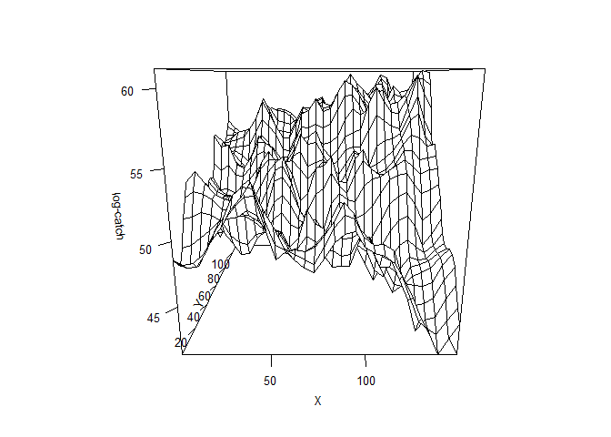

```r
persp(krg.uk,xlab="X",ylab="Y",zlab="log-catch",ticktype="detailed")
```

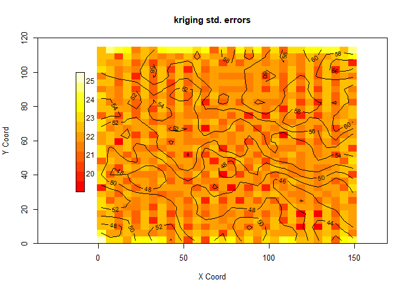

```r
image(krg.uk, val=sqrt(krg.uk$krige.var), main="kriging std. errors",
    xlim=c(-15,floor(max(X))),ylim=c(0,120));
contour(krg.uk,add=T)
legend.krige(x.leg=c(-13,-8), y.leg=c(30,100), val=krg.uk$krige.var,
  vert=TRUE, off=0.7, cex=0.9, scale.vals=pretty(krg.uk$krige.var)
)
```

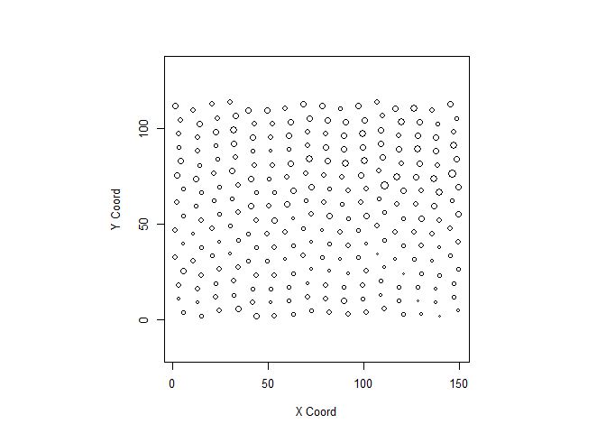

```r
points.geodata(soja.geo,pt.divide="data.proportional")
```

stima della media

```r
krg.uk$beta
```

```
##         beta0         beta1         beta2         beta3         beta4
##  4.998546e+01 -3.453553e-02  2.682163e-02 -9.281561e-06  7.409176e-05
##         beta5
##  7.958683e-04
```

```r
krg.or$beta
```

```
##     beta
## 52.76726
```

due componenti beta. stime dei parmemtri della media per quello ordinario e per quello universale (stima con trend polinomiale ha 6 coeff perchè è di secondo grado)

## Cross validazione via kriging ordinario

```r
date()  #--- ora inizio elaborazione
```

```
## [1] "Mon Apr 15 17:00:36 2019"
```

```r
#funzione che implementa da sola la cross validazione
#non prevediamo con variogramma ma su di esso si basa la previsione krig
#quindi se variogramma fa schifo previsione fa schifo
xvalid.notrend<-xvalid(soja.geo, coords = soja.geo$coords, data = soja.geo$data,
      model=soja.var.fit)
```

[output not shown]

```r
#lista di tante componenti
date()  #--- ora fine elaborazione
```

```
## [1] "Mon Apr 15 17:00:41 2019"
```

**Grafici**

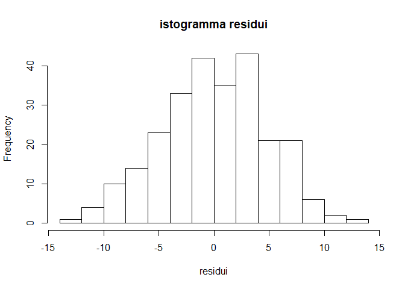

```r
hist(xvalid.notrend$error,main="istogramma residui",xlab="residui")
```

error residui di cross validazione centrati su 0

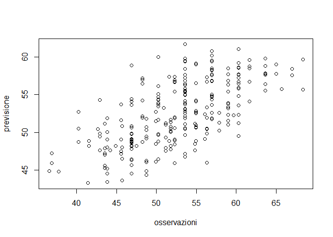

```r
plot(xvalid.notrend$data,xvalid.notrend$predicted,ylab="previsione",xlab="osservazioni")
```

i dati disponibili verso le osservazioni previste sui siti campionari + correlazione tra osservati e previsti e ci fa piacere

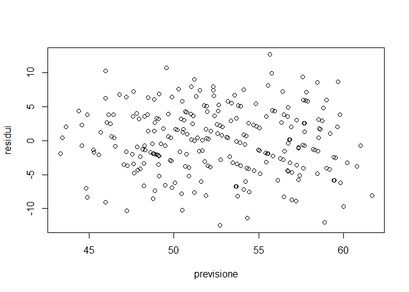

```r
plot(xvalid.notrend$predicted,xvalid.notrend$error,ylab="residui",xlab="previsione")
```

valori previsti vs errori, sparpagliato, ci piace perche non c’e andamento diverso a seconda della risposta, no eteroschedasticitÃ

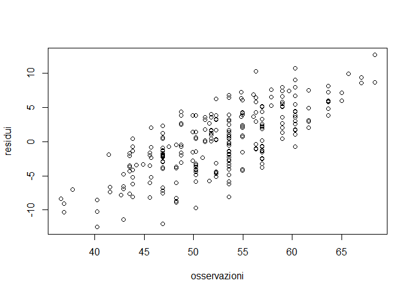

```r
plot(xvalid.notrend$data,xvalid.notrend$error,ylab="residui",xlab="osservazioni")
```

vale la pena fare loocv? togliere una sola osservazione? si perchè il kriging è un previsore esatto, la cv permette di fare diagnostica perchè altrimenti riproduco le oss e non avrei residui da trattare.

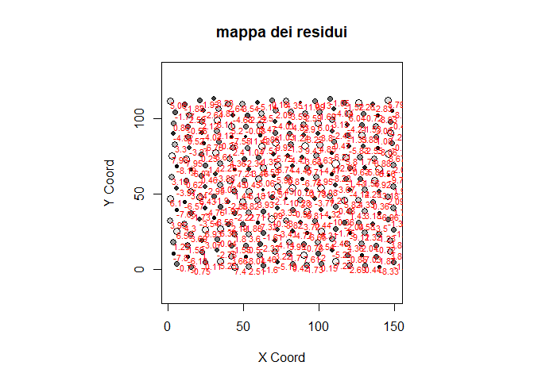

```r
 n<-length(xvalid.notrend$error)
points.geodata(coords=soja.geo$coords,data=xvalid.notrend$error,main="mappa dei residui",
        pt.divide="data.proportional",col=gray(1:n/n))
text(x=soja.geo$coords, labels=round(xvalid.notrend$error,2),cex=0.7,col=2,adj=c(0,1))
```

per ogni sito campionario valore del residuo, pallino più grande quanto più è grande il residuo; utile per capire dove sulla mappa si fanno gli errori. dove osservo pallini grandi so che la previsione in quella regione è particolarmente distorta. i residui si possono riportare sulla mappa, utile! dove l’errore è piccolo posso anche buttare via l’osservazione. dove è alto no, l’osservazione è utile perchè se la tolgo sbaglio molto

**cv per valutare previsioni**

si puÃ² usare per confrontare modelli alternativi anche misure di fit

```r
cor(xvalid.notrend$data,xvalid.notrend$predicted)
```

```
## [1] 0.6458231
```

```r
mean(xvalid.notrend$error^2)
```

```
## [1] 22.89297
```

EQM (MSE) che si può imputare alla scelta di covariogramma o variogramma; ripetendo per altre scelte si può fare un confronto

## Griglie e kriging dentro shapefile

Lettura dati

```r
a=read.table("dati_krg.csv",header=T)
obj  <- as.geodata(a,coords.col=1:2,data.col=3)
vario <- variog(obj, estimator.type="classical")    # variogramma empirico
```

```
## variog: computing omnidirectional variogram
```

```r
plot(vario, main="variogramma empirico")            # variogramma per punti
vario.fit <-variofit(vario,ini.cov.pars=c(30,10000),weights="cressie",
                     cov.model="exponential", fix.nugget=FALSE,nugget=0)
```

```
## variofit: covariance model used is exponential
## variofit: weights used: cressie
## variofit: minimisation function used: optim
```

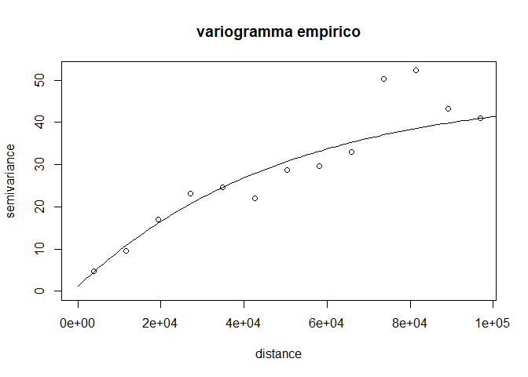

```r
cov.pars=vario.fit$cov.pars #salvo output
lines(vario.fit)
```

Lettura shape

```r
library(maptools)
library(ggplot2)
```

```r
# ricodifica del bordo come matrice  serve in krige.conv
poly<-readShapePoly("acquif.shp",verbose=TRUE)
```

```
## Shapefile type: Polygon, (5), # of Shapes: 1
```

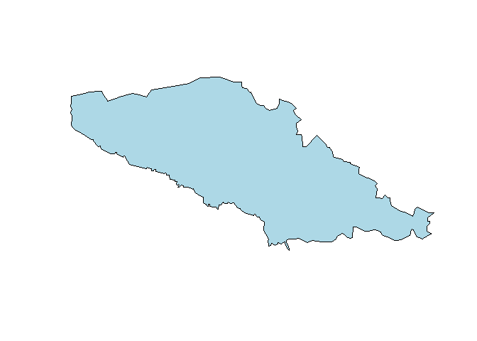

```r
plot(poly,col="lightblue")
```

```r
poligono <- fortify(poly)
  #produce un df in cui forza l'info contenuta nello shape
  #i nodi e altro, ci interessano solo lat e long

p=as.matrix(poligono[,c("long","lat")])
```

costruisco matrice coordinate griglia e kriging stessa giÃ usata prima

```r
X=bbox(poly)[1,]
Y=bbox(poly)[2,]
size=100 #con 500 pixel piÃ¹ precisi
YY<-round(seq(ceiling(min(Y)),floor(max(Y)), length=size),2)
XX<-round(seq(ceiling(min(X)),floor(max(X)), length=size),2)
griglia<-expand.grid(X=XX,Y=YY)
dim(griglia)
```

```
## [1] 10000     2
```

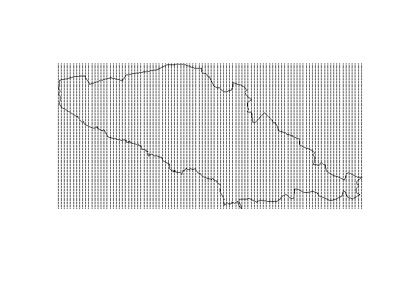

```r
plot(poly)
points(griglia,cex=0.1)
```

la griglia si sovrappone alla regione di interesse;

```r
krg.or <- krige.conv(geodata=obj,
                     loc=griglia,
                     krige=krige.control(cov.pars=cov.pars,
                                             cov.model="exponential",
                                             nugget=0),
                     borders=p)
```

```
## krige.conv: results will be returned only for prediction locations inside the borders
## krige.conv: model with constant mean
## krige.conv: Kriging performed using global neighbourhood
```

dobbiamo mettere i contorni del poligono in cui vogliamo la previsione, 2 colonne e k righe, k punti dislocati sul poligono

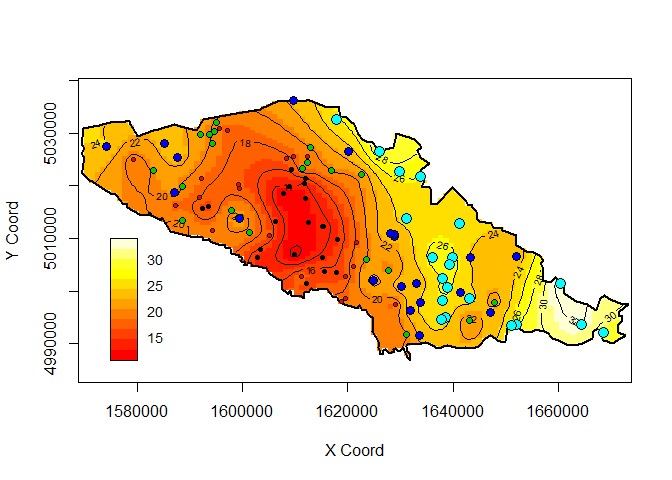

```r
image(krg.or)
legend.krige(x.leg=c(1575000, 1580000), y.leg=c(4986785, 5010000), val=krg.or$predict,
           vert=TRUE, off=0.7, cex=0.9, scale.vals=pretty(krg.or$predict)
)
contour(krg.or,add=T,coords.data=a$coords,cex=0.3)
points.geodata(obj,add=T,pt.divide="quintiles", col=1:5)
```